# BrowserHistoryPaser

### Creation d'un programme permettant de parser, traiter les données extraites à travers l'api Google history afin de les visualiser dans le dashboard en d3.js.

```python
%matplotlib inline
import datetime
import json
import tldextract
import numpy as np
import pandas as pd
import seaborn as sns
from matplotlib import pyplot as plt
from PIL import Image
```

```python
with open("BrowserHistory.json",encoding='utf_8') as f:
    data = json.loads(f.read())
    df = pd.DataFrame(data["Browser History"])
```

```python
#df.drop('client_id', axis=1, inplace=True)
#df.drop('favicon_url', axis=1, inplace=True)
df.columns
```

```
Index(['client_id', 'favicon_url', 'page_transition', 'time_usec', 'title',
       'url'],
      dtype='object')
```

Pour commencer, on doit reformater l'heure (en microsecondes) vers format datetime plus lisible. Ensuite, je devais en tirer des caractéristiques telles que l'heure, le jour, le mois ou le jour de la semaine.

```python
def convert_time(x):
    return datetime.datetime.fromtimestamp(x/1000000)
df['dt'] = df['time_usec'].apply(convert_time)
```

```python
def get_date(x):
    return str(x.date())
df['date'] = df['dt'].apply(get_date)
```

```python
def get_hour(x):
    return int(x.hour)
df['hour'] = df['dt'].apply(get_hour)
```

```python
def get_day(x):
    return int(x.day)
df['day'] = df['dt'].apply(get_day)
```

```python
def get_month(x):
    return int(x.month)
df['month'] = df['dt'].apply(get_month)
```

```python
def get_year(x):
    return int(x.year)
df['year'] = df['dt'].apply(get_year)
```

```python
def get_is_secure(x):
    if x.startswith("https"):
        return "Y"
    return "N"
df['is_secure'] = df['url'].apply(get_is_secure)
```

```python
def get_is_weekend(x):
    if x.weekday() >= 5:
        return "Y"
    return "N"
df['is_weekend'] = df['dt'].apply(get_is_weekend)
```

```python
def get_weekday(x):
    return x.weekday()+1
df['weekday'] = df['dt'].apply(get_weekday)
```

```python
days_arr = ["Mon","Tue", "Wed", "Thu", "Fri", "Sat", "Sun"]
def get_day_of_week(x):
    return days_arr[x.weekday()]
df['day_of_week'] = df['dt'].apply(get_day_of_week)
```

A Partir du champ URL, l'extraction du domaine peut constituer une donnée utile pour l'analyse. J'ai donc utilisé tldextract pour créer une nouvelle colonne de domaine dans une nouvelle colonne.

```python
def get_domain(x):
    domain = tldextract.extract(x)[1]
    sub_domain = tldextract.extract(x)[0]
    if sub_domain == "mail":
        return sub_domain + "." + domain
    if domain == "google" and sub_domain=="www":
        return "google_search"
    return domain
df['domain'] = df['url'].apply(get_domain)
```

Ensuite, j'ai extrapolé les informations de domaine pour regrouper les domaines bien connus dans l'une ou l'autre des catégories prédéfinies :

```python
def get_category(x):
    if x in ["stackoverflow","coursera", "udemy", "fast", "kaggle","github","quora","overleaf","localhost","ec-lyon"]:
        return "Learning"
    elif x in ["ycombinator", "medium", "hackernoon", "codechef"]:
        return "TechReads"
    elif x in ["facebook", "twitter", "instagram","linkedin","youtube"]:
        return "Social"
    elif x in ["mail.google", "slack.com","gmail.com"]:
        return "Email"
    elif x in ["cdiscount", "amazon", "myprotein", "dealabs"]:
        return "Shopping"
    elif x in ["airbnb", "skyscanner", "sncf", "ouibus"]:
        return "TravelBookings"
    elif x in ["google_search"]:
        return "Search"
    else:
        return "Other"
df['category'] = df['domain'].apply(get_category)
```

page_transition: Contient des informations sur le type de transition vers la page comme reload, type & enter, lien ouvert, etc. On se contente de LINK et TYPED .

```python
df = df[(df['page_transition'] == "LINK") | (df['page_transition'] == "TYPED")]
df = df[df['domain'] != 'newtab']
```

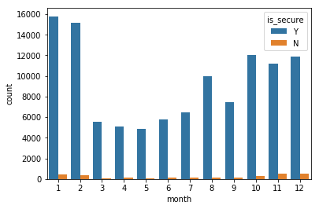

```python
sns.countplot(x="month", hue="is_secure", data=df);
```

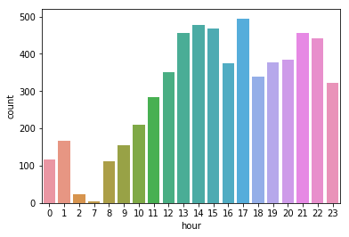

```python
sns.countplot(x="hour", data=df[(df['category'] == "Learning") ]);
```

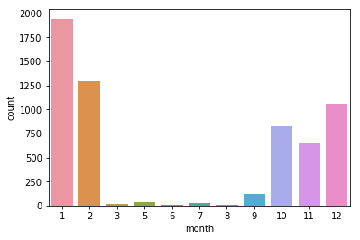

```python
sns.countplot(x="month", data=df[(df['category'] == "Learning" ) ]);
```

### Browser usage over months

```python
df_new = df[(df["month"] >= 11)].groupby(["hour", "date"])["domain"].nunique()
df_new = df_new.reset_index(name="count")
```

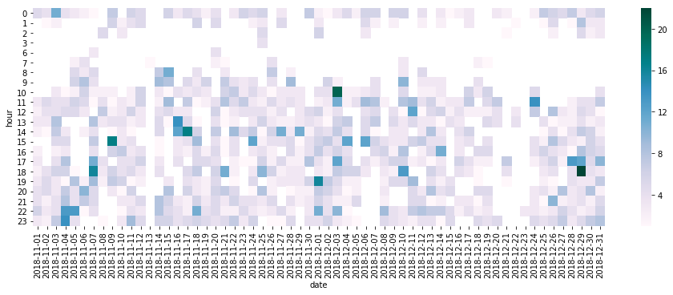

```python
plt.figure(figsize = (16,5))
sns.heatmap(df_new.pivot("hour", "date", "count"), annot=False, cmap="PuBuGn")
```

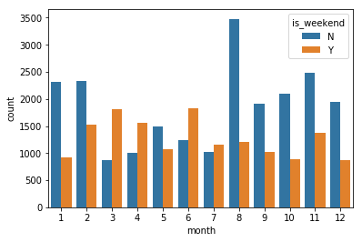

```python
sns.countplot(x="month", hue="is_weekend", data=df[(df['domain'] == "youtube")] );
```

### Facebook usage by hour

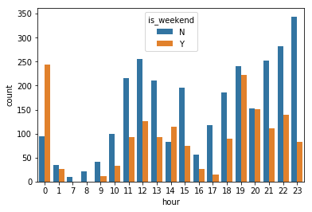

```python
sns.countplot(x="hour", hue="is_weekend", data=df[(df['domain'] == "facebook") & (df["month"] == 10)]);
```

### Category visits by month

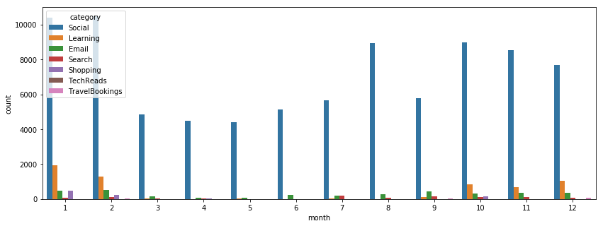

```python
plt.figure(figsize = (14,5))
sns.countplot(x="month", hue="category", data=df[df["category"] != 'Other']);
```

### Category visits by hour

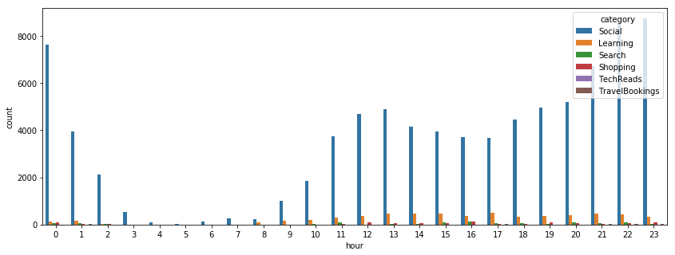

```python
plt.figure(figsize = (14,5))
sns.countplot(x="hour", hue="category", data=df[(df["category"] != 'Other') & (df["category"] != 'Email')]);
```

```python
#df['domain'].value_counts()
```

### Domain visits by month

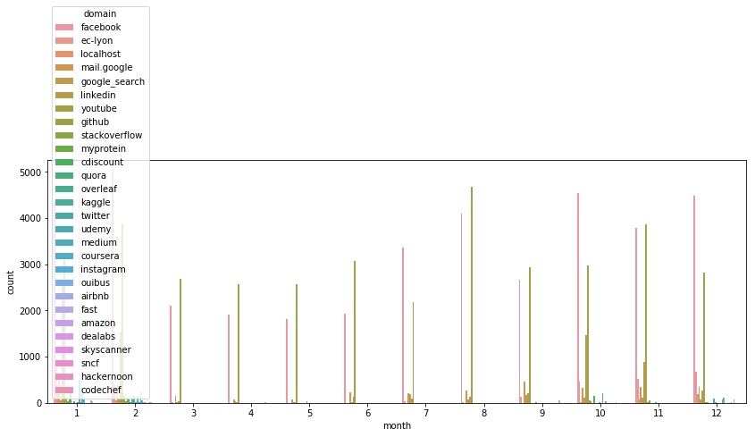

```python
plt.figure(figsize = (14,5))
sns.countplot(x="month", hue="domain", data=df[df["category"] != 'Other']);
```

### Domain visits by hour

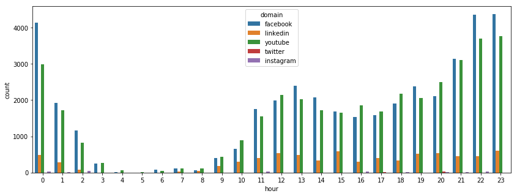

```python
plt.figure(figsize = (14,5))
sns.countplot(x="hour", hue="domain", data=df[(df["category"] == 'Social') ]);
```

### Category visits by weekday

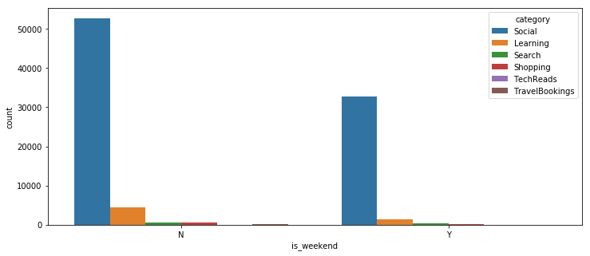

```python
plt.figure(figsize = (12,5))
sns.countplot(x="is_weekend", hue="category", data=df[(df["category"] != 'Other') & (df["category"] != 'Email')]);
```

### Creating the new json file with aggregated data

```python
df_agg = df[['time_usec','favicon_url','url', 'page_transition','year',
        'date', 'hour',  'day_of_week','domain', 'category']].where(df['year'] == 2018)
```

#### Taking only data related to the 2018 year

```python
df_agg = df_agg[df_agg.year == 2018]
```

#### Taking only data related to the used graphs in the dashboard ( to reduce file size )

```python
df_agg.columns
```

```
Index(['time_usec', 'favicon_url', 'url', 'page_transition', 'year', 'date',
       'hour', 'day_of_week', 'domain', 'category'],
      dtype='object')
```

```python
df_agg = df_agg[['time_usec','favicon_url', 'page_transition', 'date', 'hour',  'day_of_week','domain', 'category']]
```

#### Un chantillonnage aléatoire de 5000 instances peut être envisagé pour réduire la taille du fichier généré

```python
#df_agg = df_agg.sample(5000)
```

#### Génération du fichier json

```python
with open('data_out_agg.json', 'w') as f:
    f.write(df_agg.to_json(orient='records'))
```